# NOAA Storm Database Analysis - Most harmful Events

Armin Wallrab

April 26th 2015

## Introduction

Storms and other severe weather events can cause both public health and economic problems for communities and municipalities. Many severe events can result in fatalities, injuries, and property damage, and preventing such outcomes to the extent possible is a key concern.

This project involves exploring the U.S. National Oceanic and Atmospheric Administration’s (NOAA) storm database. This database tracks characteristics of major storms and weather events in the United States, including when and where they occur, as well as estimates of any fatalities, injuries, and property damage.

## Data

The data for this assignment come in the form of a comma-separated-value file compressed via the bzip2 algorithm to reduce its size. You can download the file from the course web site:

[Storm Data](https://d396qusza40orc.cloudfront.net/repdata%2Fdata%2FStormData.csv.bz2) [47Mb]

There is also some documentation of the database available. Here you will find how some of the variables are constructed/defined.

[National Weather Service Storm Data Documentation](https://d396qusza40orc.cloudfront.net/repdata%2Fpeer2_doc%2Fpd01016005curr.pdf)

[National Climatic Data Center Storm Events FAQ](https://d396qusza40orc.cloudfront.net/repdata%2Fpeer2_doc%2FNCDC%20Storm%20Events-FAQ%20Page.pdf)

The events in the database start in the year 1950 and end in November 2011. In the earlier years of the database there are generally fewer events recorded, most likely due to a lack of good records. More recent years should be considered more complete.

## Synopsis

The basic goal of this analysis is to explore the NOAA Storm Database and answer some basic questions about severe weather events. The following questions are analysed:

Across the United States, which types of events are most harmful with respect to population health?

Across the United States, which types of events have the greatest economic consequences?

## Data Processing

We use the dplyr library to subset and correct the data

```r
library(dplyr)
d <- read.csv(bzfile("repdata_data_StormData.csv.bz2"))
## reduce the data set
# select only relevant rows & columns
d <- d %>% select(EVTYPE, FATALITIES, INJURIES, PROPDMG, PROPDMGEXP, CROPDMG, CROPDMGEXP) %>%
           filter(FATALITIES > 0 | INJURIES > 0 | PROPDMG > 0 | CROPDMG > 0)
# normalize EVTYPE, PROPDMGEXP and CROPDMGEXP and group by EVTYPE
d <- d %>% mutate(EVTYPE = as.factor(toupper(as.character(EVTYPE))), PROPDMGEXP = as.factor(toupper(as.character(PROPDMGEXP))), CROPDMGEXP = as.factor(toupper(as.character(CROPDMGEXP)))) %>%
           group_by(EVTYPE)
```

Then the damage values can be calculated. Please note, in the original data set exponents are encoded with “K”, “M” and “B” to indicate thousands, millions or billions.

```r
# calculate damages
propdmgexp <- data.frame(PROPDMGEXP=c("", "K", "M", "B"), propexp=c(1, 1e3, 1e6, 1e9))
cropdmgexp <- data.frame(CROPDMGEXP=c("", "K", "M", "B"), cropexp=c(1, 1e3, 1e6, 1e9))
d <- d %>% inner_join(propdmgexp) %>%
           inner_join(cropdmgexp) %>%
           mutate(TOTALDMG = PROPDMG*propexp + CROPDMG*cropexp)
```

## Results

The events causing most damages can be calculated and shown with the following.

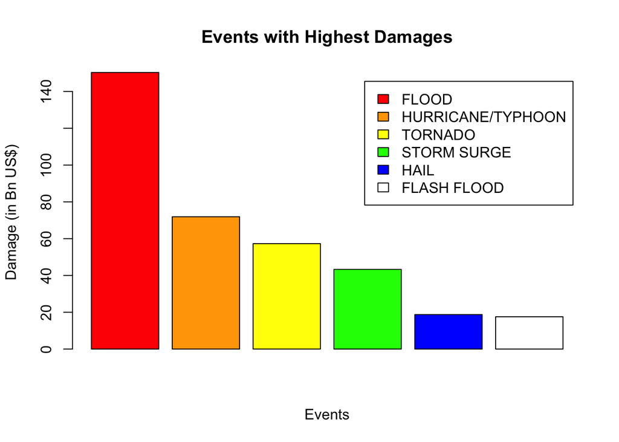

```r
# find events causing most damages
dmg <- summarize(d, damages=sum(TOTALDMG))
dmg <- head(arrange(dmg, desc(damages)))

barplot(dmg$damages/1e9, xlab = "Events", ylab = "Damage (in Bn US$)", legend.text = dmg$EVTYPE, col=c("red","orange","yellow","green","blue","white"), main="Events with Highest Damages")
```

Flooding causes the most damages (150 billion US$).

The events causing most fatalities can be calculated and shown with the following.

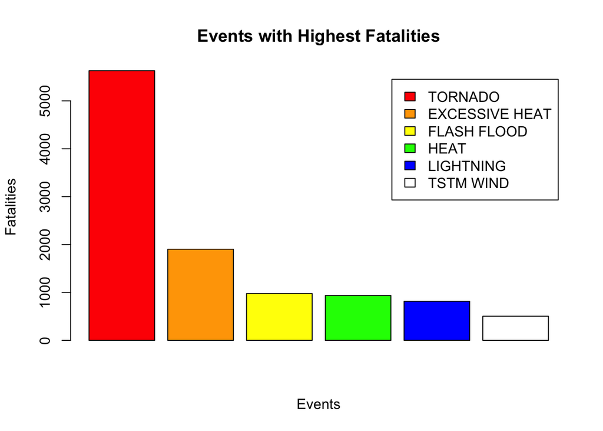

```r
fat <- summarize(d, fatalities=sum(FATALITIES))
fat <- head(arrange(fat, desc(fatalities)))

barplot(fat$fatalities, xlab = "Events", ylab = "Fatalities", legend.text = fat$EVTYPE, col=c("red","orange","yellow","green","blue","white"), main="Events with Highest Fatalities")
```

Tornados cause the most fatalities (5630).